# Regresión no Lineal: smoothing splines

Javier Cara

curso 2018-19

# 1 Modelo

Las regression splines se definen de la siguiente forma:

- Se definen los nodos.
- Los nodos generan una base de polinomios para la spline.
- Usando mínimos cuadrados se estiman los coeficientes de la base.

Hay otra manera de generar una spline, que es minimizar el funcional:

$$\textbf F[g(x)] = \sum_{i=1}^n (y_i - g(x_i))^2 + \lambda \int g''(x)^2 dx = F_1[g(x)] + F_2[g(x)]$$

donde *g(x)* es la spline, conocida como *smoothing spline*. $\lambda$ es un parámetro de ajuste.

- *F1[g(x)]* y *F2[g(x)]* son siempre positivas, por lo que minimizar *F[g(x)]* equivale a minimizar ambas.
- Si $\lambda=0$, minimizar el funcional equivale a que *g(x)* interpola todos los *yi*, produciendo un sobreajuste de los datos.
- Si $\lambda=\infty$, minimizar el funcional equivale a que *g(x)* sea una recta:
  - $g'(x)$ es una medida de la pendiente de la spline en *x*.
  - Por tanto, $g''(x)$ es una medida de como cambia la pendiente de *g(x)* en *x*.
  - $\int g''(x)^2 dx$ es la suma del cambio de la pendiente de *g(x)* en todo *x*.
  - Si $\lambda \rightarrow 0$, *F1[g(x)]* predomina sobre *F2[g(x)]*, por lo que minimizar *F[g(x)]* equivale a minimizar *F1[g(x)]*: se obtiene una spline poco suave.
  - Si $\lambda \rightarrow \infty$, *F2[g(x)]* predomina sobre *F1[g(x)]*, por lo que minimizar *F[g(x)]* equivale a minimizar *F2[g(x)]*: se obtiene la spline más suave posible, la recta.
- Se puede demostrar que, para un $\lambda$ dado, la función *g(x)* que minimiza *F[g(x)]* es una spline natural cubica con nodos en $x_1, x_2, \ldots, x_n$.
- Para $\lambda=0$, el número de grados de libertad de la spline es *n*, y para $\lambda=\infty$, el número de grados de libertad es 2 (una recta).

# 2 Estimacion del modelo

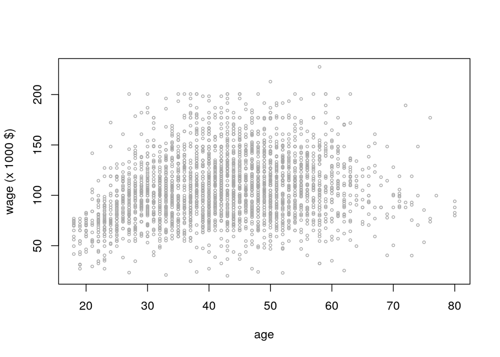

```r
library(ISLR)
datos = Wage
datos = datos[datos$wage<250,]
plot(datos$age,datos$wage, cex = 0.5, col = "darkgrey", ylab = "wage (x 1000 $)", xlab = "age")
```

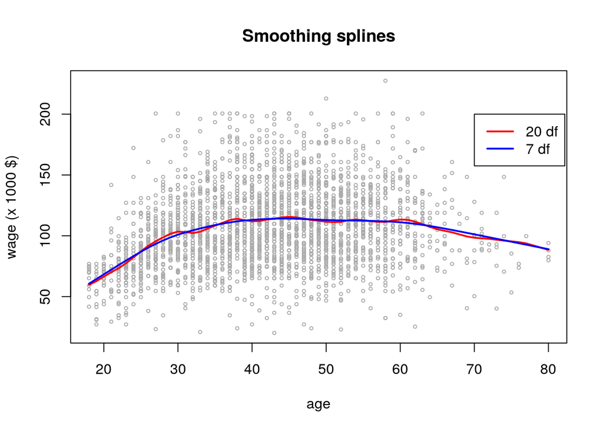

```r
m1 = smooth.spline(datos$age, datos$wage, df = 20)
m2 = smooth.spline(datos$age, datos$wage, df = 7)
plot(datos$age,datos$wage, cex = 0.5, col = "darkgrey", ylab = "wage (x 1000 $)", xlab = "age")
title("Smoothing splines")
lines(m1, col = "red", lwd = 2)
lines(m2, col = "blue", lwd = 2)
legend(70,200, legend = c("20 df", "7 df"), col = c("red","blue"), lty = 1, lwd = 2)
```

# 3 Prediccion

```r
age_grid = seq(from = min(datos$age), to = max(datos$age), by = 1)
alfa = 0.05
yp = predict(m1, newdata = data.frame(age = age_grid))
str(yp)
```

```
## List of 2
##  $ x: num [1:61] 18 19 20 21 22 23 24 25 26 27 ...
##  $ y: num [1:61] 59.6 62.7 66.4 70 73.4 ...
```

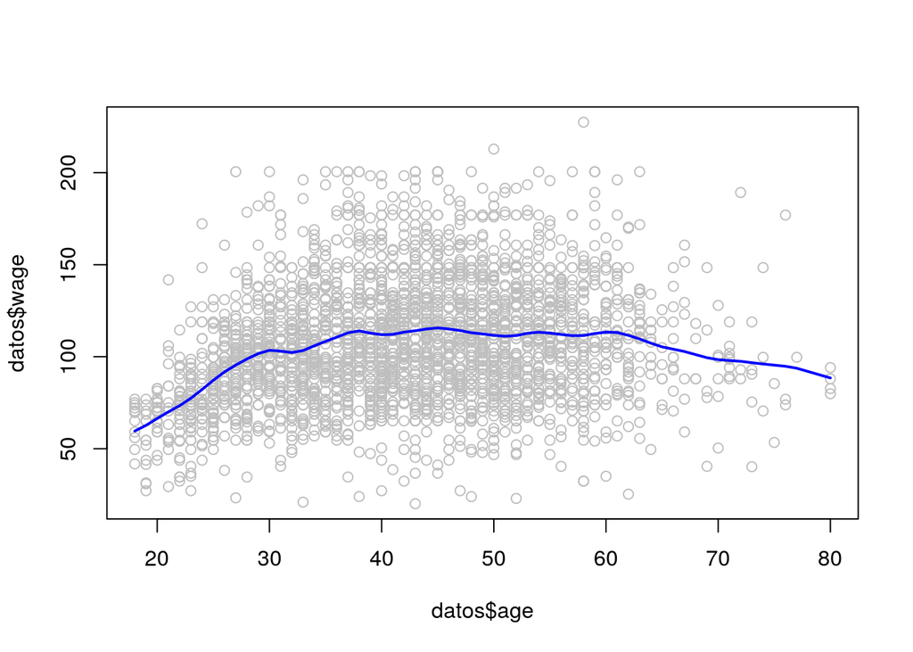

```r
plot(datos$age, datos$wage, col = "gray")
lines(yp$x, yp$y, col = "blue", lwd = 2)
```

Esta información ya está dentro de m1.